# Practical Machine Learning: Course Project

Tracy Wilson

June 20, 2015

```r
setwd("D:/Users/Tracy/Documents/R/Machine Learning/Project/Machine-Learning-Project")
library(caret, quietly=TRUE)
library(knitr, quietly=TRUE)
library(ggplot2, quietly=TRUE)
library(dplyr, quietly=TRUE)
library(randomForest, quietly=TRUE)
```

## Background

Using devices such as Jawbone Up, Nike FuelBand, and Fitbit it is now possible to collect a large amount of data about personal activity relatively inexpensively. These type of devices are part of the quantified self movement - a group of enthusiasts who take measurements about themselves regularly to improve their health, to find patterns in their behavior, or because they are tech geeks. One thing that people regularly do is quantify how much of a particular activity they do, but they rarely quantify how well they do it. In this project, myr goal will be to use data from accelerometers on the belt, forearm, arm, and dumbell of 6 participants. They were asked to perform barbell lifts correctly and incorrectly in 5 different ways.

## Prepare the Data

The data sets have been downloaded and saved to the working directory. From there they will be read into dataframes. There are 2 data sets, the training data set and the testing data set. Data will be cleanses and all “NA” and “DIV/0” will be removed.

```r
trainData <- read.csv(file = 'pml-training.csv',
                      na.strings = c('NA','#DIV/0!',''))
testData <- read.csv(file = 'pml-testing.csv',
                     na.strings = c('NA','#DIV/0!',''))
```

We take a cursory look at the data, paying particular attention to classe which is the variable we need to predict

```r
str(trainData, list.len=15)
```

```
## 'data.frame':    19622 obs. of  160 variables:
##  $ X                       : int  1 2 3 4 5 6 7 8 9 10 ...
##  $ user_name               : Factor w/ 6 levels "adelmo","carlitos",..: 2 2 2 2 2 2 2 2 2 2 ...
##  $ raw_timestamp_part_1    : int  1323084231 1323084231 1323084231 1323084232 1323084232 1323084232 1323084232 1323084232 1323084232 1323084232 ...
##  $ raw_timestamp_part_2    : int  788290 808298 820366 120339 196328 304277 368296 440390 484323 484434 ...
##  $ cvtd_timestamp          : Factor w/ 20 levels "02/12/2011 13:32",..: 9 9 9 9 9 9 9 9 9 9 ...
##  $ new_window              : Factor w/ 2 levels "no","yes": 1 1 1 1 1 1 1 1 1 1 ...
##  $ num_window              : int  11 11 11 12 12 12 12 12 12 12 ...
##  $ roll_belt               : num  1.41 1.41 1.42 1.48 1.48 1.45 1.42 1.42 1.43 1.45 ...
##  $ pitch_belt              : num  8.07 8.07 8.07 8.05 8.07 8.06 8.09 8.13 8.16 8.17 ...
##  $ yaw_belt                : num  -94.4 -94.4 -94.4 -94.4 -94.4 -94.4 -94.4 -94.4 -94.4 -94.4 ...
##  $ total_accel_belt        : int  3 3 3 3 3 3 3 3 3 3 ...
##  $ kurtosis_roll_belt      : num  NA NA NA NA NA NA NA NA NA NA ...
##  $ kurtosis_picth_belt     : num  NA NA NA NA NA NA NA NA NA NA ...
##  $ kurtosis_yaw_belt       : logi  NA NA NA NA NA NA ...
##  $ skewness_roll_belt      : num  NA NA NA NA NA NA NA NA NA NA ...
##   [list output truncated]
```

```r
str(testData, list.len=15)
```

```
## 'data.frame':    20 obs. of  160 variables:
##  $ X                       : int  1 2 3 4 5 6 7 8 9 10 ...
##  $ user_name               : Factor w/ 6 levels "adelmo","carlitos",..: 6 5 5 1 4 5 5 5 2 3 ...
##  $ raw_timestamp_part_1    : int  1323095002 1322673067 1322673075 1322832789 1322489635 1322673149 1322673128 1322673076 1323084240 1322837822 ...
##  $ raw_timestamp_part_2    : int  868349 778725 342967 560311 814776 510661 766645 54671 916313 384285 ...
##  $ cvtd_timestamp          : Factor w/ 11 levels "02/12/2011 13:33",..: 5 10 10 1 6 11 11 10 3 2 ...
##  $ new_window              : Factor w/ 1 level "no": 1 1 1 1 1 1 1 1 1 1 ...
##  $ num_window              : int  74 431 439 194 235 504 485 440 323 664 ...
##  $ roll_belt               : num  123 1.02 0.87 125 1.35 -5.92 1.2 0.43 0.93 114 ...
##  $ pitch_belt              : num  27 4.87 1.82 -41.6 3.33 1.59 4.44 4.15 6.72 22.4 ...
##  $ yaw_belt                : num  -4.75 -88.9 -88.5 162 -88.6 -87.7 -87.3 -88.5 -93.7 -13.1 ...
##  $ total_accel_belt        : int  20 4 5 17 3 4 4 4 4 18 ...
##  $ kurtosis_roll_belt      : logi  NA NA NA NA NA NA ...
##  $ kurtosis_picth_belt     : logi  NA NA NA NA NA NA ...
##  $ kurtosis_yaw_belt       : logi  NA NA NA NA NA NA ...
##  $ skewness_roll_belt      : logi  NA NA NA NA NA NA ...
##   [list output truncated]
```

```r
for(i in c(8:ncol(trainData)-1)) {
  trainData[,i] = as.numeric(as.character(trainData[,i]))
  testData[,i] = as.numeric(as.character(testData[,i]))
}
```

Further analysis shows that many of the columns do not have a great deal of data and will not be useful in building the model. We will create an index which will be used to filter the data set to use columns with full compliments of data.

```r
pertinentDataIndex <- colnames(trainData)
pertinentDataIndex <- colnames(trainData[colSums(is.na(trainData)) == 0])
pertinentDataIndex <- pertinentDataIndex[-c(1:7)]
```

## Split Data Into Training and Evaluation Groups

```r
set.seed(1255)
index_train <- createDataPartition(y=trainData$classe, p=0.70, list=FALSE)
trainDataSet <- trainData[index_train,pertinentDataIndex]
evalDataSet <- trainData[-index_train,pertinentDataIndex]
dim(trainDataSet)
```

```
## [1] 13737    53
```

```r
dim(evalDataSet)
```

```
## [1] 5885   53
```

## Premodel Fitting

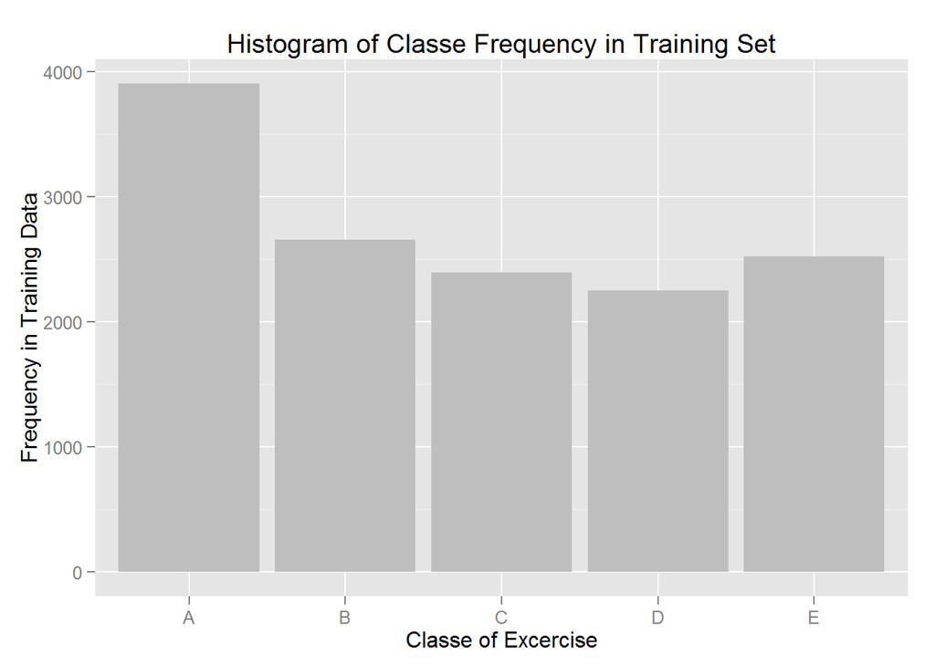

```r
ggplot(aes(x=classe), data=trainDataSet) +
    geom_histogram(fill='gray') +
    ggtitle('Histogram of Classe Frequency in Training Set') +
    xlab('Classe of Excercise') +
    ylab('Frequency in Training Data')
```

From the histogram we see that the classifications are within an order of magnitude of each other.

## Train Candidate Model and Evaluate

```r
modelRF <- train(classe ~ ., data = trainDataSet, method = 'rf',
                  trControl = trainControl(method = "cv", number = 4, allowParallel = TRUE, verboseIter = TRUE))
predictRF <- predict(modelRF,evalDataSet)
confusionRF <- confusionMatrix(predictRF,evalDataSet$classe)
```

## Predictions Against Cross Validation Data

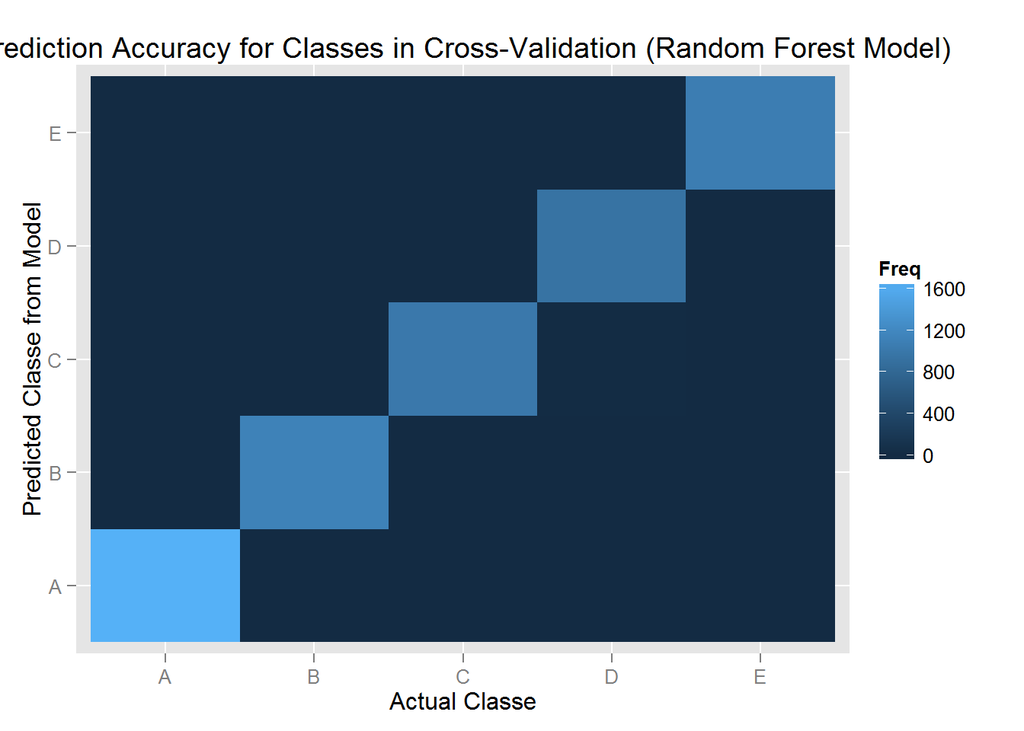

```r
ggplot(data=data.frame(confusionRF$table)) +
    geom_tile(aes(x=Reference, y=Prediction, fill=Freq)) +
    ggtitle('Prediction Accuracy for Classes in Cross-Validation (Random Forest Model)') +
    xlab('Actual Classe') +
    ylab('Predicted Classe from Model')
```

The graph above compares the predictions for each class against the actual value in the cross validation set, and colors the tile intersection for each combination of outcome class by the frequency of prediction. The intersection of Predicted Classe and Actual Class is very high for all 5 classes in the Random Forest model This indicates that the model is very accurate.

```r
confusionRF
```

```
## Confusion Matrix and Statistics
##
##           Reference
## Prediction    A    B    C    D    E
##          A 1674    7    0    0    0
##          B    0 1131    6    0    0
##          C    0    1 1019   18    0
##          D    0    0    1  946    3
##          E    0    0    0    0 1079
##
## Overall Statistics
##
##                Accuracy : 0.9939
##                  95% CI : (0.9915, 0.9957)
##     No Information Rate : 0.2845
##     P-Value [Acc > NIR] : < 2.2e-16
##
##                   Kappa : 0.9923
##  Mcnemar's Test P-Value : NA
##
## Statistics by Class:
##
##                      Class: A Class: B Class: C Class: D Class: E
## Sensitivity            1.0000   0.9930   0.9932   0.9813   0.9972
## Specificity            0.9983   0.9987   0.9961   0.9992   1.0000
## Pos Pred Value         0.9958   0.9947   0.9817   0.9958   1.0000
## Neg Pred Value         1.0000   0.9983   0.9986   0.9964   0.9994
## Prevalence             0.2845   0.1935   0.1743   0.1638   0.1839
## Detection Rate         0.2845   0.1922   0.1732   0.1607   0.1833
## Detection Prevalence   0.2856   0.1932   0.1764   0.1614   0.1833
## Balanced Accuracy      0.9992   0.9959   0.9946   0.9903   0.9986
```

The accuracy of the model is **0.9938828** . The out of sample error is **0.0061172** . The out of sample error is calculated as **0.0061172** for predictions made against the cross-validation set. With a sample size of 20, an error rate that is less than 1% is a good indication that the little or none of the test samples will be misclassified.

## Submissions to Coursera

Write submission files to local file directory.

```r
finalCol <- length(colnames(testData[]))
colnames(testData)[finalCol] <- 'classe'
answers <- predict(modelRF,testData[,pertinentDataIndex])


pml_write_files = function(x){
  n = length(x)
  for(i in 1:n){
    filename = paste0("problem_id_",i,".txt")
    write.table(x[i],file=filename,quote=FALSE,row.names=FALSE,col.names=FALSE)
  }
}

pml_write_files(answers)
```